# Modified Beta-Function Selection Model

Selection models comprises two components. The first component, herein after termed the *evidence-generating process*, models the distribution of effect sizes before selection, typically using a conventional random-effects model or meta-regression model. The second component, hereinafter termed the *selection process*, identifies how the distribution is changed based on the likelihood of an effect size being reported. The combined model provides parameter estimates that define the selection process, along with meta-analytic estimates that are adjusted for selective reporting.

Following the approach outlined in our previous paper (Pustejovsky, Citkowicz, and Joshi 2025), we model the *marginal* distribution of effect size estimates rather than the joint distribution within studies. To account for dependence among effect sizes, we use cluster-robust variance estimation or clustered bootstrap methods, which accommodate within-study correlation without requiring explicit modeling of the dependence structure. While this strategy limits interpretation to the marginal distribution and does not distinguish between study-level and outcome-level selection, it remains a practical and plausible framework for modeling selective reporting based on the significance of individual estimates.

We use the following notation to describe the model and estimation procedures. Consider a meta-analytic dataset comprising $J$ studies, where study $j$ reports $k_j$ effect size estimates. Let $y_{ij}$ denote the $i$th effect size estimate from study $j$, with associated standard error $\sigma_{ij}$ and one-sided $p$-value $p_{ij}$. The one-sided $p$-value is defined relative to the null hypothesis that the true effect is less than or equal to zero. Let $\mathbf{x}_{ij}$ be a $1 \times x$ row vector of predictors representing characteristics of the effect size, sample, or study procedures. We use $\Phi()$ to denote the standard normal cumulative distribution function and $\phi()$ to denote the standard normal density function.

## Evidence-generating process

We assume an evidence-generating process based on a standard random-effects meta-regression model. Let $Y^*$ denote a potentially reported effect size estimate, with standard error $\sigma^*$, one-sided $p$-value $p^*$, and predictor vector $\mathbf{x}^*$. Then the evidence-generating process is defined as

$$\begin{equation}
\label{eq:meta-mean-regression}
\left(Y^* | \sigma^*, \mathbf{x}^*\right) \sim N\left(\mathbf{x}^*
\boldsymbol\beta, \ \tau^2 + \sigma^{*2}\right),
\end{equation}$$

where $\boldsymbol\beta$ is an $x \times 1$ vector of regression coefficients and $\tau^2$ is the marginal variance of the effect size distribution. This model treats effect sizes as independent and characterizes *total* heterogeneity without decomposing within- and between-study variation.

## Selection process

A $p$-value selection process is defined by a selection function that specifies the probability that an effect size is reported, conditional on its $p$-value. Let $O$ indicate whether $Y^*$ is observed. The process implies that
$$\begin{equation}
\label{eq:selection-process}
\Pr\left(O = 1 | p^* \right) \propto w\left(p^*; \boldsymbol\lambda
\right)
\end{equation}$$
where $w\left(.; \boldsymbol\lambda\right)$ is a known, strictly positive function on the interval $[0, 1]$ with an unknown $h \times 1$ parameter vector $\boldsymbol\lambda$.

Citkowicz and Vevea (2017) defined the selection function using a truncated beta density with two parameters, offering flexibility to capture diverse selection patterns more parsimoniously than the step functions developed by Hedges (1992) and Vevea and Hedges (1995). Since the beta density can be unbounded near 0 and 1, they proposed truncating it to make the model computationally tractable, assuming constant selection probabilities for $p$-values in the range $[0, \alpha_1]$ and $[\alpha_2, 1]$. Given these pre-specified thresholds $\alpha_1$ and $\alpha_2$ and selection parameters $\boldsymbol\lambda = (\lambda_1, \lambda_2)$, the beta density selection function is expressed by
$$\begin{equation}
\label{eq:beta-density-p}
w(p^*_i, \boldsymbol\lambda) = \begin{cases}
\alpha_1^{\lambda_1 - 1} (1 - \alpha_1)^{\lambda_2 - 1} & \text{if}
\quad p^*_i \leq \alpha_1 \\
\left(p^*_i\right)^{\lambda_1 - 1} (1 - p^*_i)^{\lambda_2 - 1} &
\text{if} \quad \alpha_1 < p^*_i < \alpha_2 \\
\alpha_2^{\lambda_1 - 1} (1 - \alpha_2)^{\lambda_2 - 1} & \text{if}
\quad \alpha_2 \leq p^*_i.
\end{cases}
\end{equation}$$
Equation ($\ref{eq:beta-density-p}$) can be written equivalently as
$$\begin{equation}
\label{eq:beta-density-y}
w(Y^*_i / \sigma^*_i, \boldsymbol\lambda) = \begin{cases}
\alpha_1^{\lambda_1 - 1} (1 - \alpha_1)^{\lambda_2 - 1} & \text{if}
\quad \sigma^*_i \Phi^{-1}(1 - \alpha_1) \leq Y^*_i \\
\left[\Phi\left(-Y^*_i / \sigma^*_i\right)\right]^{\lambda_1 - 1}
\left[\Phi\left(Y^*_i / \sigma^*_i\right)\right]^{\lambda_2 - 1} &
\text{if} \quad \sigma^*_i \Phi^{-1}(1 - \alpha_2) < Y^*_i <
\sigma^*_i \Phi^{-1}(1 - \alpha_1) \\
\alpha_2^{\lambda_1 - 1} (1 - \alpha_2)^{\lambda_2 - 1} & \text{if}
\quad Y^*_i \leq \sigma^*_i \Phi^{-1}(1 - \alpha_2).
\end{cases}
\end{equation}$$

Citkowicz and Vevea (2017) used extreme truncation points ($\alpha_1 = 10^{-5}$, $\alpha_2 = 1 - 10^{-5}$), but such choices can make the model overly sensitive to rare, extreme $p$-values, potentially producing implausible estimates (Hedges 2017). Using more moderate, psychologically salient thresholds such as $\alpha_1 = .025$ and $\alpha_2 = .975$ could potentially reduce this sensitivity and yield more plausible selection patterns.

@ref(fig:beta-functions) shows several shapes the beta density can assume. @ref(fig:beta-functions)a. presents a typical situation in which strong preference is shown for highly significant one-sided $p$-values, where $\lambda_1 = 0.5$ and $\lambda_2 = 2.0$. @ref(fig:beta-functions)b. presents $\lambda_1 = 1$ and $\lambda_2 = 1$, which signifies no selection.

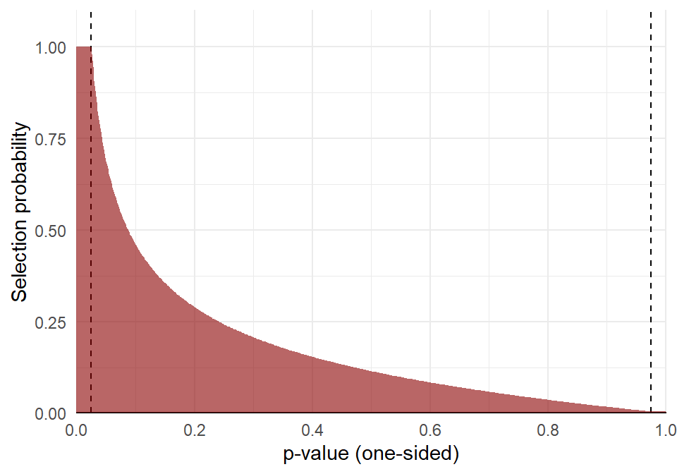

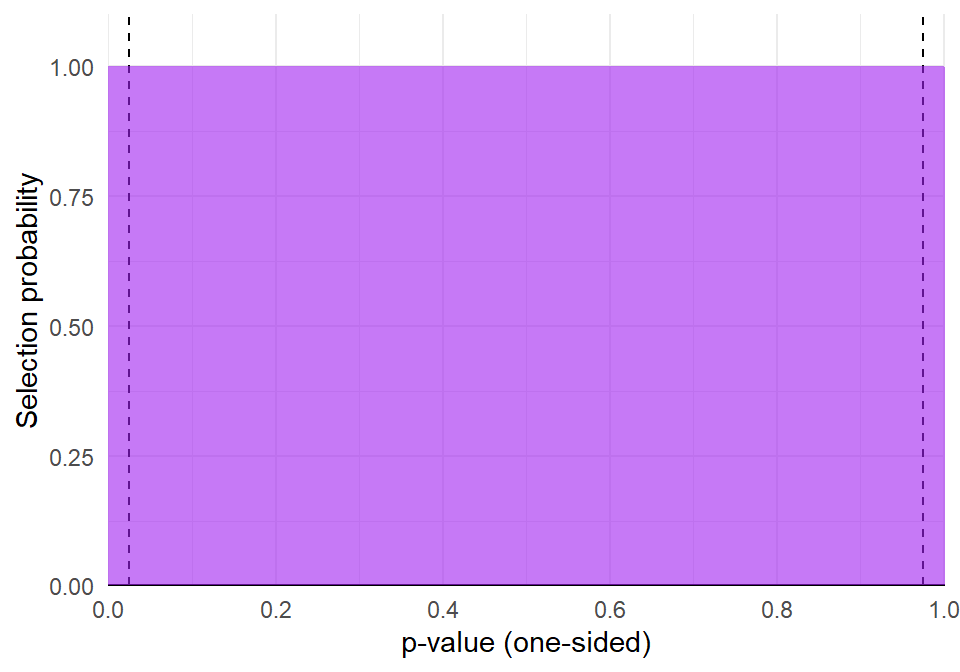

Examples of beta density functions

## Distribution of observed effect size estimates

The combined model for the marginal density of an observed effect size estimate $Y$ with standard error $\sigma$ has the form
$$\begin{equation}
\label{eq:generic-selection}
f(Y = y | \sigma, \mathbf{x}) = \frac{1}{A(\mathbf{x}, \sigma;
\boldsymbol\beta, \tau^2, \boldsymbol\lambda)} \times w\left(y, \sigma;
\boldsymbol\lambda \right) \times \frac{1}{\sqrt{\tau^2 + \sigma^2}}
\phi\left(\frac{y - \mathbf{x} \boldsymbol\beta}{\sqrt{\tau^2 +
\sigma^2}}\right),
\end{equation}$$
where
$$\begin{equation}
\label{eq:generic-selection-A}
A(\mathbf{x}, \sigma; \boldsymbol\beta, \tau^2, \boldsymbol\lambda)
= \int_\mathbb{R} w\left(y, \sigma; \boldsymbol\lambda \right)
\times \frac{1}{\sqrt{\tau^2 + \sigma^2}}\phi\left(\frac{y -
\mathbf{x}\boldsymbol\beta}{\sqrt{\tau^2 + \sigma^2}}\right) dy.
\end{equation}$$
If $w(y, \sigma; \boldsymbol\lambda) = 1$, then $A(\mathbf{x}, \sigma; \boldsymbol\beta, \tau^2, \boldsymbol\lambda) = 1$ and there is no selective reporting, as depicted in @ref(fig:beta-functions)b. The density then reduces to the unweighted density of the evidence-generating process and the $\boldsymbol\beta$ estimates from the adjusted beta function selection model will approximate those of the standard meta-analytic model.

For the beta-function selection process, the $A(\mathbf{x}, \sigma; \boldsymbol\beta, \tau^2, \boldsymbol\lambda)$ term in the beta-function composite likelihood can be computed using the closed-form expression
$$\begin{equation}
\label{eq:beta-function-A}
A_{ij} = A(\mathbf{x}_{ij}, \sigma_{ij}; \boldsymbol\beta, \tau^2,
\boldsymbol\lambda) = \alpha_1^{\lambda_1} (1 - \alpha_1)^{\lambda_2}
B_{0ij} + E_Y(1 | \lambda_1,\lambda_2) + \alpha_2^{\lambda_1} (1 -
\alpha_2)^{\lambda_2} B_{2ij}
\end{equation}$$
where
$$\begin{equation}
\label{eq:beta-function-Ey}
E_Y\left[f(Y)| \lambda_1, \lambda_2\right] = \int_{\sigma_{ij}
\Phi^{-1}(1 - \alpha_2)}^{\sigma_{ij} \Phi^{-1}(1 - \alpha_1)} f(Y)
\left[\Phi(-Y / \sigma_{ij})\right]^{\lambda_1} \left[\Phi(Y /
\sigma_{ij})\right]^{\lambda_2}
\frac{1}{\sqrt{\eta_{ij}}}\phi\left(\frac{Y -
\mu_{ij}}{\sqrt{\eta_{ij}}}\right) dY,
\end{equation}$$
$c_{hij} = \left(\sigma_{ij} \Phi^{-1}\left(1 - \alpha_h\right) - \mathbf{x}_{ij}\boldsymbol\beta\right) / \sqrt{\tau^2 + \sigma_{ij}^2}$ for $h = 1,2$, $B_{0ij} = 1 - \Phi(c_{1ij})$, and $B_{2ij} = \Phi(c_{2ij})$ (Citkowicz and Vevea 2017).

## Estimation Method

We estimate model parameters using maximum composite marginal likelihood (CML), which treats each observed effect size estimate as if it were mutually independent, following established composite likelihood approaches (e.g., Cox and Reid 2004; Lindsay 1988; Varin 2008). Estimation proceeds by maximizing a weighted log-likelihood function defined over the marginal contributions of each observation, using reparameterizations of the variance and selection parameters. Confidence intervals are constructed using robust (sandwich-type) variance estimators based on study-level score contributions. A detailed explanation of CML methods is provided in our previous paper (Pustejovsky, Citkowicz, and Joshi 2025), and the exact expressions used for estimating the beta-function selection model are presented in APPENDIX.

## Bootstrap inference

To improve inference accuracy with a limited number of studies, we also implement bootstrap procedures, which generate pseudo-samples through random resampling or reweighting of the original data. We consider both the non-parametric clustered bootstrap and the fractional random weight bootstrap (Xu et al. 2020), which differ in how they preserve the dependence structure across clusters. Confidence intervals are then computed using standard bootstrap-based methods such as the percentile, basic, studentized, and bias-corrected-and-accelerated intervals (Davison and Hinkley 1997; Efron 1987). These resampling-based procedures are particularly useful in small-sample contexts where sandwich estimators may perform poorly. APPENDIX provides further details about the bootstrap CI calculations.

Citkowicz, Martyna, and Jack L Vevea. 2017. “A parsimonious weight function for modeling publication bias.” *Psychological Methods* 22 (1): 28–41. https://doi.org/10.1037/met0000119.

Cox, D. R., and N. Reid. 2004. “A Note on Pseudolikelihood Constructed from Marginal Densities.” *Biometrika* 91 (3): 729–37. https://doi.org/10.1093/biomet/91.3.729.

Davison, A. C., and D. V. Hinkley. 1997. *Bootstrap Methods and Their Applications*. Cambridge: Cambridge University Press.

Efron, Bradley. 1987. “Better Bootstrap Confidence Intervals.” *Journal of the American Statistical Association* 82 (397): 171–85. https://doi.org/10.1080/01621459.1987.10478410.

Hedges, Larry V. 1992. “Modeling Publication Selection Effects in Meta-Analysis.” *Statistical Science* 7 (2): 246–55.

———. 2017. “Plausibility and Influence in Selection Models: A Comment on Citkowicz and Vevea (2017).” *Psychological Methods* 22 (1): 42–46. https://doi.org/10.1037/met0000108.

Lindsay, Bruce G. 1988. “Composite Likelihood Methods.” In *Contemporary Mathematics*, edited by N. U. Prabhu, 80:221–39. Providence, Rhode Island: American Mathematical Society. https://doi.org/10.1090/conm/080/999014.

Pustejovsky, James E., Martyna Citkowicz, and Megha Joshi. 2025. “Estimation and Inference for Step-Function Selection Models in Meta-Analysis with Dependent Effects.” *Journal Name*.

Varin, Cristiano. 2008. “On Composite Marginal Likelihoods.” *AStA Advances in Statistical Analysis* 92 (1): 1–28. https://doi.org/10.1007/s10182-008-0060-7.

Vevea, Jack L, and Larry V Hedges. 1995. “A General Linear Model for Estimating Effect Size in the Presence of Publication Bias.” *Psychometrika* 60 (3): 419–35. https://doi.org/10.1007/BF02294384.

Xu, Li, Chris Gotwalt, Yili Hong, Caleb B King, and William Q Meeker. 2020. “Applications of the Fractional-Random-Weight Bootstrap.” *The American Statistician* 74 (4): 345–58. https://doi.org/10.1080/00031305.2020.1731599.